# Project Two: Logistic Regression and Random Forests

For Project Two, you have been asked to create different models analyzing a Heart Disease data set. Before beginning work on the project, be sure to read through the Project Two Guidelines and Rubric to understand what you need to do and how you will be graded on this assignment. Be sure to carefully review the Project Two Summary Report template, which contains all of the questions that you will need to answer about the regression analyses you are performing.

For this project, you will be writing all the scripts yourself. You may reference the textbook and your previous work on the problem sets to help you write the scripts.

### Scenario

You are a data analyst researching risk factors for heart disease at a university hospital. You have access to a large set of historical data that you can use to analyze patterns between different health indicators (e.g. fasting blood sugar, maximum heart rate, etc.) and the presence of heart disease. You have been asked to create different logistic regression models that predict whether or not a person is at risk for heart disease. A model like this could eventually be used to evaluate medical records and look for risks that might not be obvious to human doctors. You have also been asked to create a classification random forest model to predict the risk of heart disease and a regression random forest model to predict the maximum heart rate achieved.

There are several variables in this data set, but you will be working with the following important variables:

| Variable | What does it represent? |
| --- | --- |
| age | The person's age in years |
| sex | The person's sex (1 = male, 0 = female) |
| cp | The type of chest pain experienced (0=no pain, 1=typical angina, 2=atypical angina, 3=non-anginal pain) |
| trestbps | The person's resting blood pressure |
| chol | The person's cholesterol measurement in mg/dl |
| fbs | The person's fasting blood sugar is greater than 120 mg/dl (1 = true, 0 = false) |
| restecg | Resting electrocardiographic measurement (0=normal, 1=having ST-T wave abnormality, 2=showing probable or definite left ventricular hypertrophy by Estes' criteria) |
| thalach | The person's maximum heart rate achieved |
| exang | Exercise-induced angina (1=yes, 0=no) |
| oldpeak | ST depression induced by exercise relative to rest ('ST' relates to positions on the ECG plot) |
| slope | The slope of the peak exercise ST segment (1=upsloping, 2=flat, 3=downsloping) |
| ca | The number of major vessels (0-3) |
| target | Heart disease (0=no, 1=yes) |

## Install Libraries

In the following code block, you will install appropriate libraries to use in this project.

```r
print("This step will first install three R packages. Please wait until the packages are fully installed.")
print("Once the installation is complete, this step will print 'Installation complete!'")

install.packages("ResourceSelection")
install.packages("pROC")
install.packages("rpart.plot")

print("Installation complete!")
```

```
[1] "This step will first install three R packages. Please wait until the packages are fully installed."
[1] "Once the installation is complete, this step will print 'Installation complete!'"
```

```
[1] "Installation complete!"
```

## Prepare Your Data Set

In the following code block, you have been given the R code to prepare your data set.

Click the **Run** button on the toolbar to run this code.

```r
heart_data <- read.csv(file="heart_disease.csv", header=TRUE, sep=",")

# Converting appropriate variables to factors
heart_data <- within(heart_data, {
   target <- factor(target)
   sex <- factor(sex)
   cp <- factor(cp)
   fbs <- factor(fbs)
   restecg <- factor(restecg)
   exang <- factor(exang)
   slope <- factor(slope)
   ca <- factor(ca)
   thal <- factor(thal)
})

head(heart_data, 10)

print("Number of variables")
ncol(heart_data)

print("Number of rows")
nrow(heart_data)
```

A data.frame: 10 × 14

| age <int> | sex <fct> | cp <fct> | trestbps <int> | chol <int> | fbs <fct> | restecg <fct> | thalach <int> | exang <fct> | oldpeak <dbl> | slope <fct> | ca <fct> | thal <fct> | target <fct> |
| --- | --- | --- | --- | --- | --- | --- | --- | --- | --- | --- | --- | --- | --- |
| 62 | 1 | 2 | 130 | 231 | 0 | 1 | 146 | 0 | 1.8 | 1 | 3 | 3 | 1 |
| 58 | 0 | 0 | 130 | 197 | 0 | 1 | 131 | 0 | 0.6 | 1 | 0 | 2 | 1 |
| 60 | 0 | 3 | 150 | 240 | 0 | 1 | 171 | 0 | 0.9 | 2 | 0 | 2 | 1 |
| 63 | 1 | 0 | 140 | 187 | 0 | 0 | 144 | 1 | 4.0 | 2 | 2 | 3 | 0 |
| 62 | 1 | 0 | 120 | 267 | 0 | 1 | 99 | 1 | 1.8 | 1 | 2 | 3 | 0 |
| 63 | 0 | 2 | 135 | 252 | 0 | 0 | 172 | 0 | 0.0 | 2 | 0 | 2 | 1 |
| 43 | 1 | 0 | 150 | 247 | 0 | 1 | 171 | 0 | 1.5 | 2 | 0 | 2 | 1 |
| 42 | 1 | 2 | 120 | 240 | 1 | 1 | 194 | 0 | 0.8 | 0 | 0 | 3 | 1 |
| 59 | 1 | 2 | 126 | 218 | 1 | 1 | 134 | 0 | 2.2 | 1 | 1 | 1 | 0 |
| 48 | 1 | 0 | 124 | 274 | 0 | 0 | 166 | 0 | 0.5 | 1 | 0 | 3 | 0 |

```
[1] "Number of variables"
```

14

```
[1] "Number of rows"
```

303

## Model #1 - First Logistic Regression Model

You have been asked to create a logistic regression model for heart disease *(target)* using the variables age *(age)*, resting blood pressure *(trestbps)*, exercised induced angina (exang) and maximum heart rate achieved *(thalach)*. Before writing any code, review Section 3 of the Summary Report template to see the questions you will be answering about your logistic regression model.

Run your scripts to get the outputs of your regression analysis. Then use the outputs to answer the questions in your summary report.

**Note: Use the + (plus) button to add new code blocks, if needed.**

```r
# Logistic Regression Model_1
# ------------------------------------
cat("Logistic Regression Model_1\n-------------------------------------------------\n")

# Create the complete model
model_1 <- glm(target ~ age + trestbps + thalach + exang, data = heart_data, family = "binomial")

summary(model_1)
```

```
Logistic Regression Model_1
-------------------------------------------------
```

```
Call:
glm(formula = target ~ age + trestbps + thalach + exang, family = "binomial",
    data = heart_data)

Deviance Residuals:
    Min       1Q   Median       3Q      Max
-2.0935  -0.7944   0.4954   0.8133   2.2343

Coefficients:
             Estimate Std. Error z value Pr(>|z|)
(Intercept) -1.021121   1.784194  -0.572   0.5671
age         -0.017549   0.017144  -1.024   0.3060
trestbps    -0.014888   0.008337  -1.786   0.0741 .
thalach      0.031095   0.007275   4.274 1.92e-05 ***
exang1      -1.624981   0.305774  -5.314 1.07e-07 ***
---
Signif. codes:  0 '***' 0.001 '**' 0.01 '*' 0.05 '.' 0.1 ' ' 1

(Dispersion parameter for binomial family taken to be 1)

    Null deviance: 417.64  on 302  degrees of freedom
Residual deviance: 323.14  on 298  degrees of freedom
AIC: 333.14

Number of Fisher Scoring iterations: 4
```

```r
# Hosmer-Lemeshow goodness of fit test
# ------------------------------------
cat("Hosmer-Lemeshow goodness of fit test\n-------------------------------------------------\n")

# Load required library
library(ResourceSelection)

hl = hoslem.test(model_1$y, fitted(model_1), g=50)
hl
```

```
Hosmer-Lemeshow goodness of fit test
-------------------------------------------------
```

```
ResourceSelection 0.3-6 	 2023-06-27
```

```
	Hosmer and Lemeshow goodness of fit (GOF) test

data:  model_1$y, fitted(model_1)
X-squared = 44.622, df = 48, p-value = 0.612
```

```r
# Wald’s test
# ------------------------------------
cat("Walds test with a 5% level of significance\n-------------------------------------------------")

conf_int_1 <- confint.default(model_1, level=0.95)
round(conf_int_1,4)
```

```
Walds test with a 5% level of significance
-------------------------------------------------
```

A matrix: 5 × 2 of type dbl

|  | 2.5 % | 97.5 % |
| --- | --- | --- |
| (Intercept) | -4.5181 | 2.4758 |
| age | -0.0512 | 0.0161 |
| trestbps | -0.0312 | 0.0015 |
| thalach | 0.0168 | 0.0454 |
| exang1 | -2.2243 | -1.0257 |

```r
# Confusion matrix
# ------------------------------------
cat("Confusion matrix\n-------------------------------------------------\n")

# Prepare data for prediction
target_model_data_1 <- heart_data[c('age', 'trestbps', 'thalach', 'exang')]

# Predict probabilities
pred_1 <- predict(model_1, newdata = target_model_data_1, type = 'response')
depvar_pred_1 <- as.factor(ifelse(pred_1 >= 0.5, '1', '0'))

# Create confusion matrix
conf.matrix_1 <- table(heart_data$target, depvar_pred_1)[c('0','1'), c('0','1')]
rownames(conf.matrix_1) <- paste("Actual", rownames(conf.matrix_1), sep = ": default=")
colnames(conf.matrix_1) <- paste("Prediction", colnames(conf.matrix_1), sep = ": default=")

# Print Confusion Matrix
cat("Confusion Matrix for model_1:\n")
print(conf.matrix_1)

# Extract values from the Confusion matrix
TP <- conf.matrix_1["Actual: default=1", "Prediction: default=1"]
TN <- conf.matrix_1["Actual: default=0", "Prediction: default=0"]
FP <- conf.matrix_1["Actual: default=0", "Prediction: default=1"]
FN <- conf.matrix_1["Actual: default=1", "Prediction: default=0"]
cat("\n")

# Print values from the Confusion matrix
print(paste("True Positives: ", TP))
print(paste("True Negatives: ", TN))
print(paste("False Positives: ", FP))
print(paste("False Negatives: ", FN))
print(paste("Total Observations: ", TP + TN + FP + FN))
cat("\n")

# Calculate and Print Accuracy, Precision, and Recall
Accuracy <- round((TP + TN) / (TP + TN + FP + FN), 3)
cat("Accuracy: ", Accuracy, "/", Accuracy*100, "%\n")

Precision <- round(TP / (TP + FP), 3)
cat("Precision: ", Precision, "/", Precision*100, "%\n")

Recall <- round(TP / (TP + FN), 3)
cat("Recall: ", Recall, "/", Recall*100, "%\n")
```

```
Confusion matrix
-------------------------------------------------
Confusion Matrix for model_1:
                   depvar_pred_1
                    Prediction: default=0 Prediction: default=1
  Actual: default=0                    89                    49
  Actual: default=1                    31                   134

[1] "True Positives:  134"
[1] "True Negatives:  89"
[1] "False Positives:  49"
[1] "False Negatives:  31"
[1] "Total Observations:  303"

Accuracy:  0.736 / 73.6 %
Precision:  0.732 / 73.2 %
Recall:  0.812 / 81.2 %
```

```
Receiver Operating Characteristic (ROC) and (AUC)
-------------------------------------------------
```

```
[1] "Area Under the Curve (AUC)"
```

0.8007

```
[1] "ROC Curve"
```

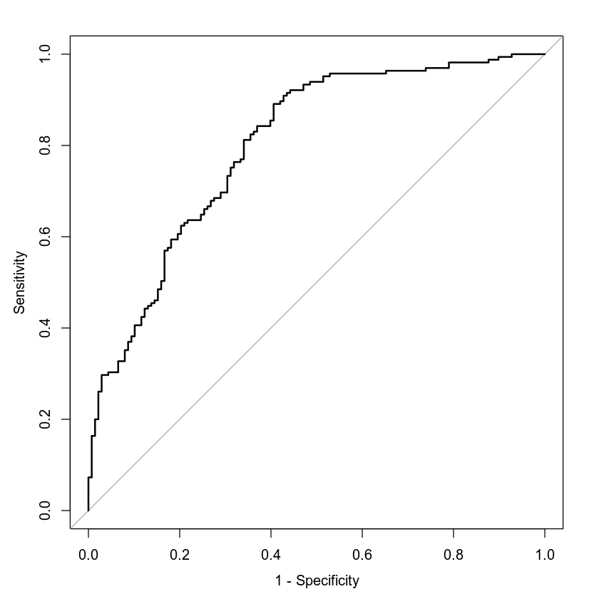

```r
# Receiver Operating Characteristic (ROC) and (AUC)
# -------------------------------------------------

# Load required library
library(pROC)

cat("Receiver Operating Characteristic (ROC) and (AUC)\n-------------------------------------------------\n")

labels <- heart_data$target
predictions <- model_1$fitted.values

roc_1 <- roc(labels ~ predictions)

print("Area Under the Curve (AUC)")
round(auc(roc_1),4)

print("ROC Curve")
# True Positive Rate (Sensitivity) and False Positive Rate (1 - Specificity)
plot(roc_1, legacy.axes = TRUE)
```

```r
# Making Predictions Using Model_1)
# -------------------------------------------------
cat("Making Predictions Using Model_1\n-------------------------------------------------\n")

print("Prediction for an individual having heart disease, 50 years old, resting blood pressure of 122, maximum heart rate of 140, and has exercise induced angina.")
newdata1_1 <- data.frame(age=50, trestbps=122, thalach=140, exang="1")
pred1_1 <- predict(model_1, newdata1_1, type='response')
cat()
cat("Probability of heart disease:", round(pred1_1, 4), "or approximately", round(pred1_1, 3)*100, "%\n")
odds1 <- pred1_1 / (1-pred1_1)
cat("Odds to heart disease:", round(odds1, 4))

cat("\n\n")

print("Prediction for an individual having heart disease, 50 years old, resting blood pressure of 130, maximum heart rate of 165, and does not has exercise induced angina.")
newdata1_2 <- data.frame(age=50, trestbps=130, thalach=165, exang="0")
pred1_2 <- predict(model_1, newdata1_2, type='response')
cat()
cat("Probability of heart disease:", round(pred1_2, 4), "or approximately", round(pred1_2, 3)*100, "%\n")
odds2 <- pred1_2 / (1-pred1_2)
cat("Odds to heart disease:", round(odds2, 4))
```

```
Making Predictions Using Model_1
-------------------------------------------------
[1] "Prediction for an individual having heart disease, 50 years old, resting blood pressure of 122, maximum heart rate of 140, and has exercise induced angina."
Probability of heart disease: 0.2716 or approximately 27.2 %
Odds to heart disease: 0.3728

[1] "Prediction for an individual having heart disease, 50 years old, resting blood pressure of 130, maximum heart rate of 165, and does not has exercise induced angina."
Probability of heart disease: 0.7853 or approximately 78.5 %
Odds to heart disease: 3.6571
```

## Model #2 - Second Logistic Regression Model

You have been asked to create a logistic regression model for heart disease *(target)* using the variables age of the individual *(age)*, resting blood pressure (trestbps), type of chest pain *(cp)* and maximum heart rate achieved *(thalach)*. You also have to include the quadratic term for age and the interaction term between age and maximum heart rate achieved. Before writing any code, review Section 4 of the Summary Report template to see the questions you will be answering about your model.

Run your scripts to get the outputs of your analysis. Then use the outputs to answer the questions in your summary report.

**Note: Use the + (plus) button to add new code blocks, if needed.**

```r
# Logistic Regression Model_2
# ------------------------------------
cat("Logistic Regression Model_2\n-------------------------------------------------\n")

# Create the complete model for heart disease (target)
# using variables age (age), resting blood pressure (trestbps), maximum heart rate achieved (thalach),
# type of chest pain experienced (cp), quadratic term for age,
# and the interaction term between age and maximum heart rate achieved
model_2 <- glm(target ~ age + trestbps + thalach + cp + age:thalach + I(age^2), data = heart_data, family = "binomial")

summary(model_2)
```

```
Logistic Regression Model_2
-------------------------------------------------
```

```
Call:
glm(formula = target ~ age + trestbps + thalach + cp + age:thalach +
    I(age^2), family = "binomial", data = heart_data)

Deviance Residuals:
    Min       1Q   Median       3Q      Max
-2.6961  -0.7537   0.2925   0.7123   2.3058

Coefficients:
              Estimate Std. Error z value Pr(>|z|)
(Intercept) -1.556e+01  1.054e+01  -1.476  0.13988
age          1.744e-01  2.669e-01   0.653  0.51357
trestbps    -1.958e-02  8.978e-03  -2.181  0.02916 *
thalach      1.363e-01  5.119e-02   2.663  0.00775 **
cp1          1.913e+00  4.437e-01   4.313 1.61e-05 ***
cp2          2.037e+00  3.473e-01   5.867 4.45e-09 ***
cp3          1.777e+00  5.477e-01   3.245  0.00117 **
I(age^2)     8.424e-04  1.750e-03   0.481  0.63025
age:thalach -1.867e-03  8.909e-04  -2.095  0.03616 *
---
Signif. codes:  0 '***' 0.001 '**' 0.01 '*' 0.05 '.' 0.1 ' ' 1

(Dispersion parameter for binomial family taken to be 1)

    Null deviance: 417.64  on 302  degrees of freedom
Residual deviance: 293.67  on 294  degrees of freedom
AIC: 311.67

Number of Fisher Scoring iterations: 5
```

```r
# Hosmer-Lemeshow goodness of fit test
# ------------------------------------
cat("Hosmer-Lemeshow goodness of fit test\n-------------------------------------------------\n")

# Load required library
library(ResourceSelection)

hl = hoslem.test(model_2$y, fitted(model_2), g=50)
hl
```

```
Hosmer-Lemeshow goodness of fit test
-------------------------------------------------
```

```
	Hosmer and Lemeshow goodness of fit (GOF) test

data:  model_2$y, fitted(model_2)
X-squared = 52, df = 48, p-value = 0.3209
```

```r
# Wald’s test
# ------------------------------------
cat("Walds test with a 5% level of significance\n-------------------------------------------------")

conf_int_2 <- confint.default(model_2, level=0.95)
round(conf_int_2,4)
```

```
Walds test with a 5% level of significance
-------------------------------------------------
```

A matrix: 9 × 2 of type dbl

|  | 2.5 % | 97.5 % |
| --- | --- | --- |
| (Intercept) | -36.2272 | 5.0999 |
| age | -0.3488 | 0.6975 |
| trestbps | -0.0372 | -0.0020 |
| thalach | 0.0360 | 0.2367 |
| cp1 | 1.0439 | 2.7830 |
| cp2 | 1.3566 | 2.7178 |
| cp3 | 0.7039 | 2.8507 |
| I(age^2) | -0.0026 | 0.0043 |
| age:thalach | -0.0036 | -0.0001 |

```r
# Confusion matrix
# ------------------------------------
cat("Confusion matrix\n-------------------------------------------------\n")

# Prepare data for prediction
target_model_data_2 <- heart_data[c('age', 'trestbps', 'thalach', 'cp')]

# Predict probabilities
pred_2 <- predict(model_2, newdata = target_model_data_2, type = 'response')
depvar_pred_2 <- as.factor(ifelse(pred_2 >= 0.5, '1', '0'))

# Create confusion matrix
conf.matrix_2 <- table(heart_data$target, depvar_pred_2)[c('0','1'), c('0','1')]
rownames(conf.matrix_2) <- paste("Actual", rownames(conf.matrix_2), sep = ": default=")
colnames(conf.matrix_2) <- paste("Prediction", colnames(conf.matrix_2), sep = ": default=")

# Print Confusion Matrix
cat("Confusion Matrix for model_2:\n")
print(conf.matrix_2)

# Extract values from the Confusion matrix
TP <- conf.matrix_2["Actual: default=1", "Prediction: default=1"]
TN <- conf.matrix_2["Actual: default=0", "Prediction: default=0"]
FP <- conf.matrix_2["Actual: default=0", "Prediction: default=1"]
FN <- conf.matrix_2["Actual: default=1", "Prediction: default=0"]
cat("\n")

# Print values from the Confusion matrix
print(paste("True Positives: ", TP))
print(paste("True Negatives: ", TN))
print(paste("False Positives: ", FP))
print(paste("False Negatives: ", FN))
print(paste("Total Observations: ", TP + TN + FP + FN))
cat("\n")

# Calculate and Print Accuracy, Precision, and Recall
Accuracy <- round((TP + TN) / (TP + TN + FP + FN), 3)
cat("Accuracy: ", Accuracy, "/", Accuracy*100, "%\n")

Precision <- round(TP / (TP + FP), 3)
cat("Precision: ", Precision, "/", Precision*100, "%\n")

Recall <- round(TP / (TP + FN), 3)
cat("Recall: ", Recall, "/", Recall*100, "%\n")
```

```
Confusion matrix
-------------------------------------------------
Confusion Matrix for model_2:
                   depvar_pred_2
                    Prediction: default=0 Prediction: default=1
  Actual: default=0                   102                    36
  Actual: default=1                    36                   129

[1] "True Positives:  129"
[1] "True Negatives:  102"
[1] "False Positives:  36"
[1] "False Negatives:  36"
[1] "Total Observations:  303"

Accuracy:  0.762 / 76.2 %
Precision:  0.782 / 78.2 %
Recall:  0.782 / 78.2 %
```

```
Receiver Operating Characteristic (ROC) and (AUC)
-------------------------------------------------
```

```
[1] "Area Under the Curve (AUC)"
```

0.8478

```
[1] "ROC Curve"
```

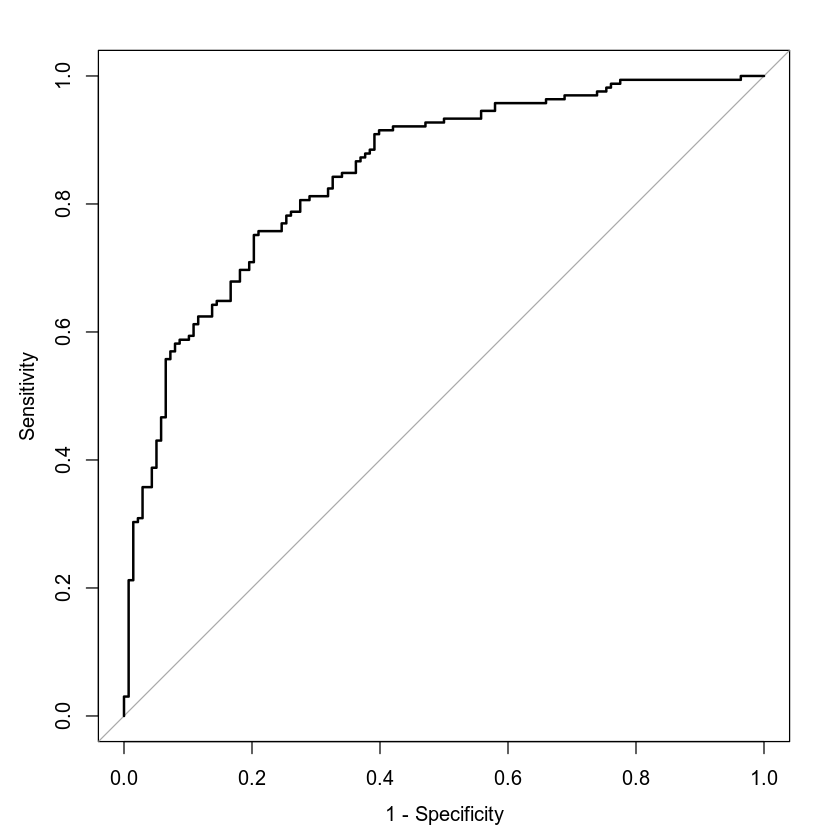

```r
# Receiver Operating Characteristic (ROC) and (AUC)
# -------------------------------------------------

# Load required library
library(pROC)

cat("Receiver Operating Characteristic (ROC) and (AUC)\n-------------------------------------------------\n")

labels <- heart_data$target
predictions <- model_2$fitted.values

roc_2 <- roc(labels ~ predictions)

print("Area Under the Curve (AUC)")
round(auc(roc_2),4)

print("ROC Curve")
# True Positive Rate (Sensitivity) and False Positive Rate (1 - Specificity)
plot(roc_2, legacy.axes = TRUE)
```

```r
# Making Predictions Using Model_2)
# -------------------------------------------------
cat("Making Predictions Using Model_2\n-------------------------------------------------\n")

print("Prediction for an individual having heart disease, 50 years old, resting blood pressure of 115, maximum heart rate of 133, and does not experience chest pain.")
newdata2_1 <- data.frame(age=50, trestbps=115, thalach=133, cp="0")
pred2_1 <- predict(model_2, newdata2_1, type='response')
cat()
cat("Probability of heart disease:", round(pred2_1, 4), "or approximately", round(pred2_1, 3)*100, "%\n")
odds2_1 <- pred2_1 / (1-pred2_1)
cat("Odds to heart disease:", round(odds2_1, 4))

cat("\n\n")

print("Prediction for an individual having heart disease, 50 years old, resting blood pressure of 125, maximum heart rate of 155, and experiences typical angina.")
newdata2_2 <- data.frame(age=50, trestbps=125, thalach=155, cp="1")
pred2_2 <- predict(model_2, newdata2_2, type='response')
cat()
cat("Probability of heart disease:", round(pred2_2, 4), "or approximately", round(pred2_2, 3)*100, "%\n")
odds2_2 <- pred2_2 / (1-pred2_2)
cat("Odds to heart disease:", round(odds2_2, 4))
```

```
Making Predictions Using Model_2
-------------------------------------------------
[1] "Prediction for an individual having heart disease, 50 years old, resting blood pressure of 115, maximum heart rate of 133, and does not experience chest pain."
Probability of heart disease: 0.2188 or approximately 21.9 %
Odds to heart disease: 0.28

[1] "Prediction for an individual having heart disease, 50 years old, resting blood pressure of 125, maximum heart rate of 155, and experiences typical angina."
Probability of heart disease: 0.8007 or approximately 80.1 %
Odds to heart disease: 4.0176
```

## Random Forest Classification Model

You have been asked to create a random forest classification model for the presence of heart disease *(target)* using the variables age *(age)*, sex *(sex)*, chest pain type *(cp)*, resting blood pressure *(trestbps)*, cholesterol measurement *(chol)*, resting electrocardiographic measurement *(restecg)*, exercise-induced angina *(exang)*, and number of major vessels *(ca)*. Before writing any code, review Section 5 of the Summary Report template to see the questions you will be answering about your model.

Run your scripts to get the outputs of your regression analysis. Then use the outputs to answer the questions in your summary report.

**Note: Use the + (plus) button to add new code blocks, if needed.**

```r
# Random Forest Classification Model
# ------------------------------------
cat("\tRandom Forest Classification Model\n==================================================\n\n")

vars <- c('target','age','sex', 'cp', 'trestbps', 'chol', 'restecg', 'exang', 'ca')

# Create data set for the Random Forest Classification Model
heart_data_RF1 <- heart_data[vars]

print("head")
head(heart_data_RF1, 5)

cat("Number of Rows:", nrow(heart_data_RF1), "\t\tNumber of Columns:", ncol(heart_data_RF1), "\n\n")
```

```
	Random Forest Classification Model
==================================================

[1] "head"
```

A data.frame: 5 × 9

| target <fct> | age <int> | sex <fct> | cp <fct> | trestbps <int> | chol <int> | restecg <fct> | exang <fct> | ca <fct> |
| --- | --- | --- | --- | --- | --- | --- | --- | --- |
| 1 | 62 | 1 | 2 | 130 | 231 | 1 | 0 | 3 |
| 1 | 58 | 0 | 0 | 130 | 197 | 1 | 0 | 0 |
| 1 | 60 | 0 | 3 | 150 | 240 | 1 | 0 | 0 |
| 0 | 63 | 1 | 0 | 140 | 187 | 0 | 1 | 2 |
| 0 | 62 | 1 | 0 | 120 | 267 | 1 | 1 | 2 |

```
Number of Rows: 303 		Number of Columns: 9
```

```r
# Install required packages for the Random Forest Classification Models.
# install.packages("randomForest")
```

```r
# Splitting Data into Training and Testing Sets

set.seed(6522048)

# Partition the data set into training and testing data sets by the 85%/15% ratio.
samp.size <- floor(0.85*nrow(heart_data_RF1))

# Define training set
train_ind <- sample(seq_len(nrow(heart_data_RF1)), size = samp.size)
train.data <- heart_data_RF1[train_ind, ]
cat("Number of rows for the training set:", nrow(train.data), "\n")

# Define testing set
test.data <- heart_data_RF1[-train_ind, ]
cat("Number of rows for the testing set:", nrow(test.data), "\n")
```

```
Number of rows for the training set: 257
Number of rows for the testing set: 46
```

```r
# Build the Random Forest Classification Model.

library(randomForest)
set.seed(6522048)

# Grow a random forest with 150 trees and 8 randomly chosen attributes
model_RFC_150 <- randomForest(target ~ age + sex + cp + trestbps + chol + restecg + exang + ca, data=train.data, ntree = 150)
print(model_RFC_150)
```

```
Call:
 randomForest(formula = target ~ age + sex + cp + trestbps + chol +      restecg + exang + ca, data = train.data, ntree = 150)
               Type of random forest: classification
                     Number of trees: 150
No. of variables tried at each split: 2

        OOB estimate of  error rate: 15.56%
Confusion matrix:
    0   1 class.error
0 100  20   0.1666667
1  20 117   0.1459854
```

```r
set.seed(6522048)

cat('Confusion Matrix: TRAINING set based on random forest model built using 150 trees
====================================================================================')
train.data.predict <- predict(model_RFC_150, train.data, type = "class")

# Construct the confusion matrix for TRAINING
conf.matrix_RFC_150 <- table(train.data$target, train.data.predict)[,c('0','1')]
rownames(conf.matrix_RFC_150) <- paste("Actual", rownames(conf.matrix_RFC_150), sep = ": ")
colnames(conf.matrix_RFC_150) <- paste("Prediction", colnames(conf.matrix_RFC_150), sep = ": ")

# Print formatted confusion matrix
format(conf.matrix_RFC_150, justify = "centre", digit=2)


cat('Confusion Matrix: TESTING set based on random forest model built using 150 trees
====================================================================================')
test.data.predict <- predict(model_RFC_150, test.data, type = "class")

# Construct the confusion matrix for TESTING
conf.matrix_RFC_150 <- table(test.data$target, test.data.predict)[,c('0','1')]
rownames(conf.matrix_RFC_150) <- paste("Actual", rownames(conf.matrix_RFC_150), sep = ": ")
colnames(conf.matrix_RFC_150) <- paste("Prediction", colnames(conf.matrix_RFC_150), sep = ": ")

# Print formatted confusion matrix
format(conf.matrix_RFC_150, justify = "centre", digit=2)

# Extract values from the Confusion matrix for TRAINING
TP <- conf.matrix_RFC_150["Actual: 1", "Prediction: 1"]
TN <- conf.matrix_RFC_150["Actual: 0", "Prediction: 0"]
FP <- conf.matrix_RFC_150["Actual: 0", "Prediction: 1"]
FN <- conf.matrix_RFC_150["Actual: 1", "Prediction: 0"]
cat("\n")

# Print values from the Confusion matrix
print(paste("True Positives: ", TP))
print(paste("True Negatives: ", TN))
print(paste("False Positives: ", FP))
print(paste("False Negatives: ", FN))
print(paste("Total Observations: ", TP + TN + FP + FN))
cat("\n")

# Calculate and Print Accuracy, Precision, and Recall
Accuracy <- round((TP + TN) / (TP + TN + FP + FN), 3)
cat("Accuracy: ", Accuracy, "/", Accuracy*100, "%\n")

Precision <- round(TP / (TP + FP), 3)
cat("Precision: ", Precision, "/", Precision*100, "%\n")

Recall <- round(TP / (TP + FN), 3)
cat("Recall: ", Recall, "/", Recall*100, "%\n")
```

```
Confusion Matrix: TRAINING set based on random forest model built using 150 trees
====================================================================================
```

A matrix: 2 × 2 of type chr

|  | Prediction: 0 | Prediction: 1 |
| --- | --- | --- |
| Actual: 0 | 119 | 1 |
| Actual: 1 | 1 | 136 |

```
Confusion Matrix: TESTING set based on random forest model built using 150 trees
====================================================================================
```

A matrix: 2 × 2 of type chr

|  | Prediction: 0 | Prediction: 1 |
| --- | --- | --- |
| Actual: 0 | 11 | 7 |
| Actual: 1 | 6 | 22 |

```
[1] "True Positives:  22"
[1] "True Negatives:  11"
[1] "False Positives:  7"
[1] "False Negatives:  6"
[1] "Total Observations:  46"

Accuracy:  0.717 / 71.7 %
Precision:  0.759 / 75.9 %
Recall:  0.786 / 78.6 %
```

[output not shown]

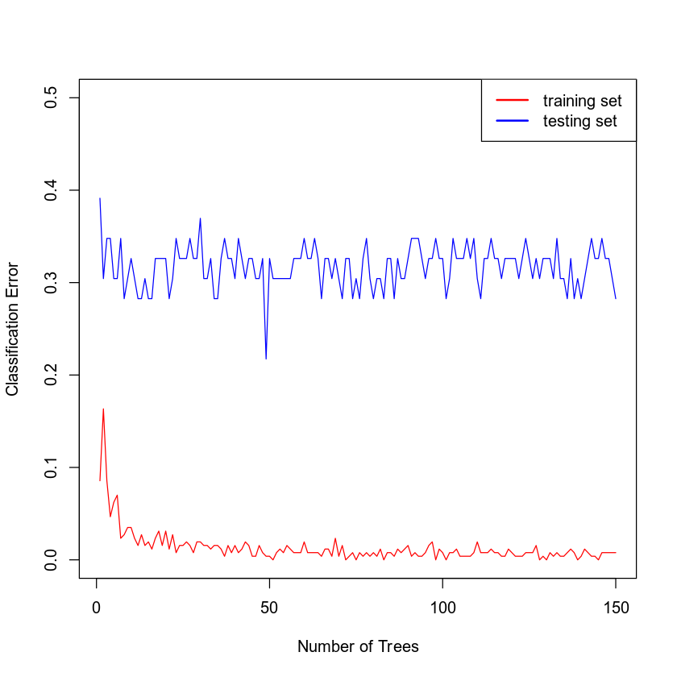

```r
# Graphing the Training and Testing Error Against the Number of Trees

set.seed(6522048)
library(randomForest)

print("Graph of the training and testing error against the number of trees using a classification random forest model for the presence of heart disease (target) using variables age, sex, chest pain type, resting blood pressure, cholesterol measurement, resting electrocardiographic measurement, exercise-induced angina, and number of major vessels (ca).")


# checking
#=====================================================================
train = c()
test = c()
trees = c()

for(i in seq(from=1, to=150, by=1)) {
    #print(i)

    trees <- c(trees, i)

    model_RFC_150 <- randomForest(target ~ age + sex + cp + trestbps + chol + restecg + exang + ca, data=train.data, ntree = i)

    train.data.predict <- predict(model_RFC_150, train.data, type = "class")
    conf.matrix1 <- table(train.data$target, train.data.predict)
    train_error = 1-(sum(diag(conf.matrix1)))/sum(conf.matrix1)
    train <- c(train, train_error)

    test.data.predict <- predict(model_RFC_150, test.data, type = "class")
    conf.matrix2 <- table(test.data$target, test.data.predict)
    test_error = 1-(sum(diag(conf.matrix2)))/sum(conf.matrix2)
    test <- c(test, test_error)
}

plot(trees, train,type = "l",ylim=c(0,0.5),col = "red", xlab = "Number of Trees", ylab = "Classification Error")
lines(test, type = "l", col = "blue")
legend('topright',legend = c('training set','testing set'), col = c("red","blue"), lwd = 2 )
```

```r
# Grow a random forest with 50 trees and 8 randomly chosen attributes
set.seed(6522048)
model_RFC_50 <- randomForest(target ~ age + sex + cp + trestbps + chol + restecg + exang + ca, data=train.data, ntree = 50)
print(model_RFC_50)
```

```
Call:
 randomForest(formula = target ~ age + sex + cp + trestbps + chol +      restecg + exang + ca, data = train.data, ntree = 50)
               Type of random forest: classification
                     Number of trees: 50
No. of variables tried at each split: 2

        OOB estimate of  error rate: 16.34%
Confusion matrix:
   0   1 class.error
0 95  25   0.2083333
1 17 120   0.1240876
```

```r
cat('Confusion Matrix: TRAINING set based on random forest model built using 50 trees
====================================================================================')
set.seed(6522048)

train.data.predict <- predict(model_RFC_50, train.data, type = "class")

# Construct the confusion matrix for TRAINING
conf.matrix_RFC_50 <- table(train.data$target, train.data.predict)[,c('0','1')]
rownames(conf.matrix_RFC_50) <- paste("Actual", rownames(conf.matrix_RFC_50), sep = ": ")
colnames(conf.matrix_RFC_50) <- paste("Prediction", colnames(conf.matrix_RFC_50), sep = ": ")

# Print formatted confusion matrix
format(conf.matrix_RFC_50, justify = "centre", digit=2)

# Extract values from the Confusion matrix for TRAINING
TP <- conf.matrix_RFC_50["Actual: 1", "Prediction: 1"]
TN <- conf.matrix_RFC_50["Actual: 0", "Prediction: 0"]
FP <- conf.matrix_RFC_50["Actual: 0", "Prediction: 1"]
FN <- conf.matrix_RFC_50["Actual: 1", "Prediction: 0"]
cat("\n")

# Print values from the Confusion matrix
print(paste("True Positives: ", TP))
print(paste("True Negatives: ", TN))
print(paste("False Positives: ", FP))
print(paste("False Negatives: ", FN))
print(paste("Total Observations: ", TP + TN + FP + FN))
cat("\n")

# Calculate and Print Accuracy, Precision, and Recall
Accuracy <- round((TP + TN) / (TP + TN + FP + FN), 3)
cat("Accuracy: ", Accuracy, "/", Accuracy*100, "%\n")

Precision <- round(TP / (TP + FP), 3)
cat("Precision: ", Precision, "/", Precision*100, "%\n")

Recall <- round(TP / (TP + FN), 3)
cat("Recall: ", Recall, "/", Recall*100, "%\n")


cat('
Confusion Matrix: TESTING set based on random forest model built using 50 trees
====================================================================================')
test.data.predict <- predict(model_RFC_50, test.data, type = "class")

# Construct the confusion matrix for TESTING
conf.matrix_RFC_50 <- table(test.data$target, test.data.predict)[,c('0','1')]
rownames(conf.matrix_RFC_50) <- paste("Actual", rownames(conf.matrix_RFC_50), sep = ": ")
colnames(conf.matrix_RFC_50) <- paste("Prediction", colnames(conf.matrix_RFC_50), sep = ": ")

# Print formatted confusion matrix
format(conf.matrix_RFC_50, justify = "centre", digit=2)

# Extract values from the Confusion matrix for TRAINING
TP <- conf.matrix_RFC_50["Actual: 1", "Prediction: 1"]
TN <- conf.matrix_RFC_50["Actual: 0", "Prediction: 0"]
FP <- conf.matrix_RFC_50["Actual: 0", "Prediction: 1"]
FN <- conf.matrix_RFC_50["Actual: 1", "Prediction: 0"]
cat("\n")

# Print values from the Confusion matrix
print(paste("True Positives: ", TP))
print(paste("True Negatives: ", TN))
print(paste("False Positives: ", FP))
print(paste("False Negatives: ", FN))
print(paste("Total Observations: ", TP + TN + FP + FN))
cat("\n")

# Calculate and Print Accuracy, Precision, and Recall
Accuracy <- round((TP + TN) / (TP + TN + FP + FN), 3)
cat("Accuracy: ", Accuracy, "/", Accuracy*100, "%\n")

Precision <- round(TP / (TP + FP), 3)
cat("Precision: ", Precision, "/", Precision*100, "%\n")

Recall <- round(TP / (TP + FN), 3)
cat("Recall: ", Recall, "/", Recall*100, "%\n")
```

```
Confusion Matrix: TRAINING set based on random forest model built using 50 trees
====================================================================================
```

A matrix: 2 × 2 of type chr

|  | Prediction: 0 | Prediction: 1 |
| --- | --- | --- |
| Actual: 0 | 117 | 3 |
| Actual: 1 | 0 | 137 |

```
[1] "True Positives:  137"
[1] "True Negatives:  117"
[1] "False Positives:  3"
[1] "False Negatives:  0"
[1] "Total Observations:  257"

Accuracy:  0.988 / 98.8 %
Precision:  0.979 / 97.9 %
Recall:  1 / 100 %

Confusion Matrix: TESTING set based on random forest model built using 50 trees
====================================================================================
```

A matrix: 2 × 2 of type chr

|  | Prediction: 0 | Prediction: 1 |
| --- | --- | --- |
| Actual: 0 | 11 | 7 |
| Actual: 1 | 9 | 19 |

```
[1] "True Positives:  19"
[1] "True Negatives:  11"
[1] "False Positives:  7"
[1] "False Negatives:  9"
[1] "Total Observations:  46"

Accuracy:  0.652 / 65.2 %
Precision:  0.731 / 73.1 %
Recall:  0.679 / 67.9 %
```

## Random Forest Regression Model

You have been asked to create a random forest regression model for maximum heart rate achieved using the variables age *(age)*, sex *(sex)*, chest pain type *(cp)*, resting blood pressure *(trestbps)*, cholesterol measurement *(chol)*, resting electrocardiographic measurement *(restecg)*, exercise-induced angina *(exang)*, and number of major vessels *(ca)*. Before writing any code, review Section 6 of the Summary Report template to see the questions you will be answering about your model.

Run your scripts to get the outputs of your analysis. Then use the outputs to answer the questions in your summary report.

**Note: Use the + (plus) button to add new code blocks, if needed.**

```r
# Random Forest Regression Model
# ------------------------------------
cat("\tRandom Forest Regression Model\n==================================================\n\n")
set.seed(6522048)

vars <- c('thalach','age','sex', 'cp', 'trestbps', 'chol', 'restecg', 'exang', 'ca')

# Create data set for the Random Forest Classification Model
heart_data_RF2 <- heart_data[vars]

print("head")
head(heart_data_RF2, 5)

cat("Number of Rows:", nrow(heart_data_RF2), "\t\tNumber of Columns:", ncol(heart_data_RF2), "\n\n")
```

```
	Random Forest Regression Model
==================================================

[1] "head"
```

A data.frame: 5 × 9

| thalach <int> | age <int> | sex <fct> | cp <fct> | trestbps <int> | chol <int> | restecg <fct> | exang <fct> | ca <fct> |
| --- | --- | --- | --- | --- | --- | --- | --- | --- |
| 146 | 62 | 1 | 2 | 130 | 231 | 1 | 0 | 3 |
| 131 | 58 | 0 | 0 | 130 | 197 | 1 | 0 | 0 |
| 171 | 60 | 0 | 3 | 150 | 240 | 1 | 0 | 0 |
| 144 | 63 | 1 | 0 | 140 | 187 | 0 | 1 | 2 |
| 99 | 62 | 1 | 0 | 120 | 267 | 1 | 1 | 2 |

```
Number of Rows: 303 		Number of Columns: 9
```

```r
# Splitting Data into Training and Testing Sets

set.seed(6522048)

# Partition the data set into training and testing data sets by the 80%/20% ratio.
samp.size <- floor(0.8*nrow(heart_data_RF2))

# Define training set
train_ind <- sample(seq_len(nrow(heart_data_RF2)), size = samp.size)
train.data <- heart_data_RF2[train_ind, ]
cat("Number of rows for the training set:", nrow(train.data), "\n")

# Define testing set
test.data <- heart_data_RF2[-train_ind, ]
cat("Number of rows for the testing set:", nrow(test.data), "\n")
```

```
Number of rows for the training set: 242
Number of rows for the testing set: 61
```

[output not shown]

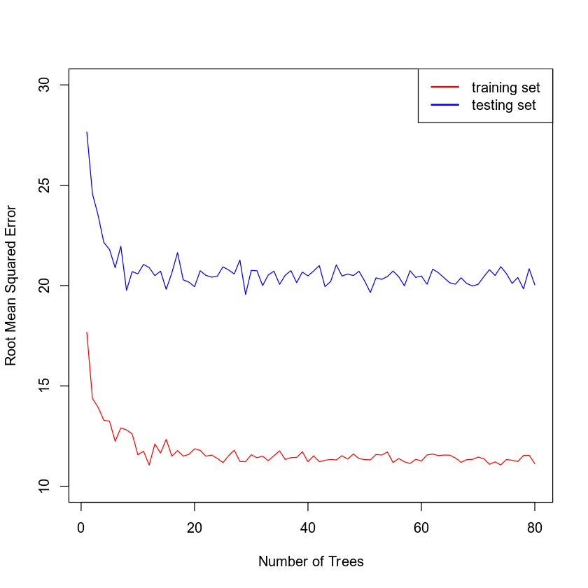

```r
# Graphing the Training and Testing Error Against the Number of Trees

set.seed(6522048)
library(randomForest)

# Root mean squared error
RMSE = function(pred, obs) {
    return(sqrt( sum( (pred - obs)^2 )/length(pred) ) )
}

print("Graph of the training and testing error against the number of trees using a random forest regression model for maximum heart rate achieved using variables age, sex, chest pain type, resting blood pressure, cholesterol measurement, resting electrocardiographic measurement, exercise-induced angina, and number of major vessels.")

# checking
#=====================================================================
train = c()
test = c()
trees = c()

for(i in seq(from=1, to=80, by=1)) {
    trees <- c(trees, i)
    model_rf80 <- randomForest(thalach ~ age + sex + cp + trestbps + chol + restecg + exang + ca, data=train.data, ntree = i)

    pred <- predict(model_rf80, newdata=train.data, type='response')
    rmse_train <-  RMSE(pred, train.data$thalach)
    train <- c(train, rmse_train)

    pred <- predict(model_rf80, newdata=test.data, type='response')
     rmse_test <-  RMSE(pred, test.data$thalach)
    test <- c(test, rmse_test)
}

plot(trees, train,type = "l",ylim=c(10,30),col = "red", xlab = "Number of Trees", ylab = "Root Mean Squared Error")
lines(test, type = "l", col = "blue")
legend('topright',legend = c('training set','testing set'), col = c("red","blue"), lwd = 2 )
```

```r
# Grow a random forest with 20 trees and 8 randomly chosen attributes
set.seed(6522048)

# Root mean squared error
RMSE = function(pred, obs) {
    return(sqrt( sum( (pred - obs)^2 )/length(pred) ) )
}

model_rf20 <- randomForest(thalach ~ age + sex + cp + trestbps + chol + restecg + exang + ca, data=train.data, ntree = 20)
print(model_rf20)

print("==========================================================================================")
print('Root Mean Squared Error: TRAINING set based on random forest model built using 20 trees')
pred <- predict(model_rf20, newdata=train.data, type='response')
round(RMSE(pred, train.data$thalach), 4)


print("==========================================================================================")
print('Root Mean Squared Error: TESTING set based on random forest model built using 20 trees')
pred <- predict(model_rf20, newdata=test.data, type='response')
round(RMSE(pred, test.data$thalach), 4)
```

[output not shown]

```
[1] "=========================================================================================="
[1] "Root Mean Squared Error: TRAINING set based on random forest model built using 20 trees"
```

11.6282

```
[1] "=========================================================================================="
[1] "Root Mean Squared Error: TESTING set based on random forest model built using 20 trees"
```

21.1139

## End of Project Two Jupyter Notebook

The HTML output can be downloaded by clicking **File**, then **Download as**, then **HTML**. Be sure to answer all of the questions in the Summary Report template for Project Two, and to include your completed Jupyter Notebook scripts as part of your submission.